# Prediction Assignment

AbdulAziz Ascandari

2024-09-21

## Background

In recent years, the proliferation of wearable devices such as Jawbone Up, Nike FuelBand, and Fitbit has made it increasingly easy and affordable to collect extensive data on personal activities. These devices have become integral tools for the quantified self movement—a community of individuals who systematically track various aspects of their lives. The primary motivations for this practice include improving health, identifying behavioral patterns, and exploring technology. While there is a wealth of data available on the quantity of activities performed, there is a notable gap in quantifying the quality or effectiveness of these activities.

## Aim

In this project, the objective is to utilize data collected from accelerometers placed on the belt, forearm, arm, and dumbbell of six participants. These participants were instructed to perform barbell lifts, both correctly and incorrectly, in five distinct ways. The analysis and modeling for this project will be conducted using the h2o library, a powerful tool for machine learning.The data for the analysis is taken from http://web.archive.org/web/20161224072740/http:/groupware.les.inf.puc-rio.br/har.

## Analysis

### Load Libraries

Here, we shall employ the h2o library for our prediction.

```r
library(h2o)
library(caret)
```

```r
library(ggplot2)
library(dplyr)
library(tidyr)
```

### Load and clean data

```r
set.seed(1234)
training <- read.csv("pml-training.csv")

# Remove near-zero variance features
nzv <- nearZeroVar(training)
training_clean <- training[, -nzv]

# Remove columns with more than 95% missing values
na_cols <- sapply(training_clean, function(x) mean(is.na(x))) > 0.95
train_clean <- training_clean[, !na_cols]

# Remove irrelevant columns (e.g., identifiers)
train_clean <- train_clean[, -c(1:7)]  # Adjust the range as needed
```

### Data Splitting

```r
# Initialize H2O cluster
h2o.init()
```

[output not shown]

```r
# Convert data to H2O frame
train_h2o <- as.h2o(train_clean)
```

[output not shown]

```r
# Split into train, validation, and test sets (70%, 15%, 15%)
splits <- h2o.splitFrame(data = train_h2o, ratios = c(0.7, 0.15), seed = 1234)
train <- h2o.assign(splits[[1]], "train")
valid <- h2o.assign(splits[[2]], "valid")
test  <- h2o.assign(splits[[3]], "test")
```

# Model Training

### Gradient Boosting

```r
# Convert the response column 'classe' to a factor (categorical variable)
train$classe <- as.factor(train$classe)
valid$classe <- as.factor(valid$classe)

y <- "classe"
x <- setdiff(names(train), y)

# Train GBM model
gbm_model <- h2o.gbm(
  x = x, y = y,
  training_frame = train,
  validation_frame = valid,
  ntrees = 500, max_depth = 6, learn_rate = 0.1,
  seed = 1234
)
```

[output not shown]

### Random Forest

```r
rf_model <- h2o.randomForest(
  x = x, y = y,
  training_frame = train,
  validation_frame = valid,
  ntrees = 500, max_depth = 6,
  seed = 1234
)
```

[output not shown]

### Naive Bayes

```r
nb_model <- h2o.naiveBayes(
  x = x, y = y,
  training_frame = train,
  validation_frame = valid,
  nfolds = 10,
  seed = 1234
)
```

[output not shown]

### XGBoost

```r
xgb_model <- h2o.xgboost(
  x = x, y = y,
  training_frame = train,
  validation_frame = valid,
  seed = 1234
)
```

[output not shown]

# Model Evaluation

### Compare R-squared for Each Model

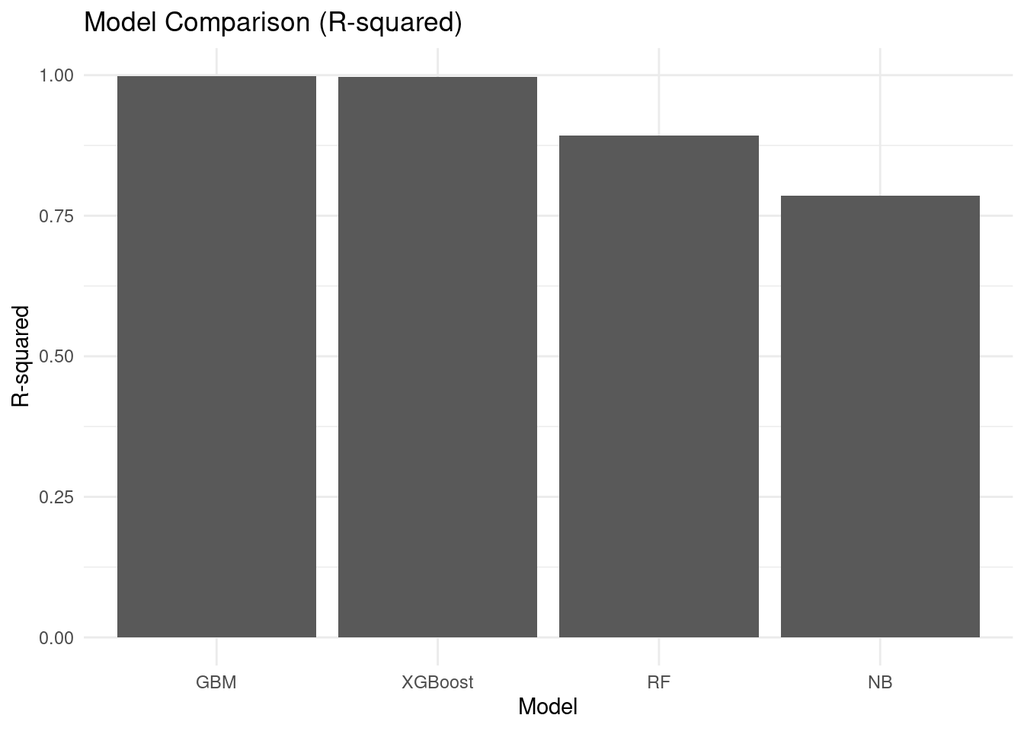

```r
rsquare <- data.frame(
  Model = c("GBM", "RF", "NB", "XGBoost"),
  R2 = c(
    h2o.r2(gbm_model, valid = TRUE),
    h2o.r2(rf_model, valid = TRUE),
    h2o.r2(nb_model, valid = TRUE),
    h2o.r2(xgb_model, valid = TRUE)
  )
)

# Plot the R-squared values
ggplot(rsquare, aes(x = reorder(Model, -R2), y = R2)) +
  geom_bar(stat = "identity") +
  theme_minimal() +
  labs(title = "Model Comparison (R-squared)", x = "Model", y = "R-squared")
```

From the R^2 plot the GBM model is selected. The confusion matrix is then printed.

### Confusion matrix of the selected Model (GBM)

```r
h2o.confusionMatrix(gbm_model, valid = TRUE)
```

```
## Confusion Matrix: Row labels: Actual class; Column labels: Predicted class
##          A   B   C   D   E  Error         Rate
## A      816   1   0   0   0 0.0012 =    1 / 817
## B        1 574   0   0   0 0.0017 =    1 / 575
## C        0   2 527   1   0 0.0057 =    3 / 530
## D        0   0   6 469   0 0.0126 =    6 / 475
## E        0   0   0   2 541 0.0037 =    2 / 543
## Totals 817 577 533 472 541 0.0044 = 13 / 2,940
```

### Variable Importance Plot (GBM)

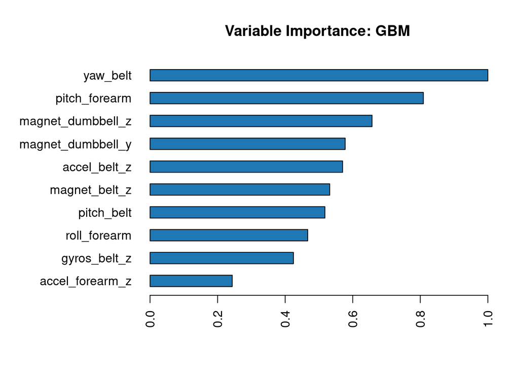

```r
h2o.varimp_plot(gbm_model)
```

# Model Testing

## Load Test Data

```r
test_data <- read.csv("pml-testing.csv")
test_h2o <- as.h2o(test_data)
```

[output not shown]

## Predict Using the GBM Model

```r
predictions <- h2o.predict(gbm_model, test_h2o)
```

[output not shown]

```r
predicted_classes <- as.data.frame(predictions$predict)
print(predicted_classes)
```

```
##    predict
## 1        B
## 2        A
## 3        B
## 4        A
## 5        A
## 6        E
## 7        D
## 8        B
## 9        A
## 10       A
## 11       B
## 12       C
## 13       B
## 14       A
## 15       E
## 16       E
## 17       A
## 18       B
## 19       B
## 20       B
```